# HTTPie: a CLI, cURL-like tool for humans

HTTPie (pronounced *aych-tee-tee-pie*) is a **command line HTTP client**. Its goal is to make CLI interaction with web services as **human-friendly** as possible. It provides a simple `http` command that allows for sending arbitrary HTTP requests using a simple and natural syntax, and displays colorized output. HTTPie can be used for **testing, debugging**, and generally **interacting** with HTTP servers.

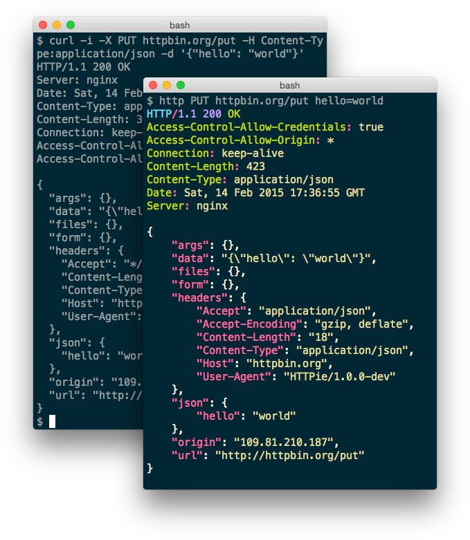

HTTPie is written in Python, and under the hood it uses the excellent Requests_ and Pygments_ libraries.

# 1 Usage

Hello World:

```bash
$ http httpie.org
```

Synopsis:

```bash
$ http [flags] [METHOD] URL [ITEM [ITEM]]
```

See also `http --help`.

## 1.1 Examples

Custom HTTP method_, HTTP headers_ and JSON_ data:

```bash
$ http PUT example.org X-API-Token:123 name=John
```

Submitting forms_:

```bash
$ http -f POST example.org hello=World
```

See the request that is being sent using one of the output options_:

```bash
$ http -v example.org
```

Use Github API_ to post a comment on an [issue](https://github.com/jkbrzt/httpie/issues/83) with authentication_:

```bash
$ http -a USERNAME POST https://api.github.com/repos/jkbrzt/httpie/issues/83/comments body='HTTPie is awesome!'
```

Upload a file using redirected input_:

```bash
$ http example.org < file.json
```

Download a file and save it via redirected output_:

```bash
$ http example.org/file > file
```

Download a file `wget` style:

```bash
$ http --download example.org/file
```

Use named sessions_ to make certain aspects or the communication persistent between requests to the same host:

```bash
$ http --session=logged-in -a username:password httpbin.org/get API-Key:123

$ http --session=logged-in httpbin.org/headers
```

Set a custom `Host` header to work around missing DNS records:

```bash
$ http localhost:8000 Host:example.com
```

*What follows is a detailed documentation. It covers the command syntax, advanced usage, and also features additional examples.*

# 2 HTTP Method

The name of the HTTP method comes right before the URL argument:

```bash
$ http DELETE example.org/todos/7
```

Which looks similar to the actual `Request-Line` that is sent:

```
DELETE /todos/7 HTTP/1.1
```

When the `METHOD` argument is **omitted** from the command, HTTPie defaults to either `GET` (with no request data) or `POST` (with request data).

# 3 Request URL

The only information HTTPie needs to perform a request is a URL. The default scheme is, somewhat unsurprisingly, `http://`, and can be omitted from the argument – `http example.org` works just fine.

Additionally, curl-like shorthand for localhost is supported. This means that, for example `:3000` would expand to `http://localhost:3000` If the port is omitted, then port 80 is assumed.

```bash
$ http :/foo
```

```
GET /foo HTTP/1.1
Host: localhost
```

```bash
$ http :3000/bar
```

```
GET /bar HTTP/1.1
Host: localhost:3000
```

```bash
$ http :
```

```
GET / HTTP/1.1
Host: localhost
```

If you find yourself manually constructing URLs with **querystring parameters** on the terminal, you may appreciate the `param==value` syntax for appending URL parameters so that you don't have to worry about escaping the `&` separators. To search for `HTTPie` on Google Images you could use this command:

```bash
$ http GET www.google.com search==HTTPie tbm==isch
```

```
GET /?search=HTTPie&tbm=isch HTTP/1.1
```

# 4 Request Items

There are a few different *request item* types that provide a convenient mechanism for specifying HTTP headers, simple JSON and form data, files, and URL parameters.

They are key/value pairs specified after the URL. All have in common that they become part of the actual request that is sent and that their type is distinguished only by the separator used: `:`, `=`, `:=`, `==`, `@`, `=@`, and `:=@`. The ones with an `@` expect a file path as value.

| Item Type | Description |
| --- | --- |
| HTTP Headers `Name:Value` | Arbitrary HTTP header, e.g. `X-API-Token:123`. |
| URL parameters `name==value` | Appends the given name/value pair as a query string parameter to the URL. The `==` separator is used. |
| Data Fields `field=value`, `field=@file.txt` | Request data fields to be serialized as a JSON object (default), or to be form-encoded (`--form, -f`). |
| Raw JSON fields `field:=json`, `field:=@file.json` | Useful when sending JSON and one or more fields need to be a `Boolean`, `Number`, nested `Object`, or an `Array`, e.g., `meals:='["ham","spam"]'` or `pies:=[1,2,3]` (note the quotes). |
| Form File Fields `field@/dir/file` | Only available with `--form, -f`. For example `screenshot@~/Pictures/img.png`. The presence of a file field results in a `multipart/form-data` request. |

You can use `\` to escape characters that shouldn't be used as separators (or parts thereof). For instance, `foo\==bar` will become a data key/value pair (`foo=` and `bar`) instead of a URL parameter.

You can also quote values, e.g. `foo="bar baz"`.

Note that data fields aren't the only way to specify request data: Redirected input_ allows for passing arbitrary data to be sent with the request.

# 5 JSON

JSON is the *lingua franca* of modern web services and it is also the **implicit content type** HTTPie by default uses:

If your command includes some data items, they are serialized as a JSON object by default. HTTPie also automatically sets the following headers, both of which can be overwritten:

| `Content-Type` | `application/json` |
| --- | --- |
| `Accept` | `application/json` |

You can use `--json, -j` to explicitly set `Accept` to `application/json` regardless of whether you are sending data (it's a shortcut for setting the header via the usual header notation – `http url Accept:application/json`).

Simple example:

```bash
$ http PUT example.org name=John email=john@example.org
```

```
PUT / HTTP/1.1
Accept: application/json
Accept-Encoding: gzip, deflate
Content-Type: application/json
Host: example.org

{
    "name": "John",
    "email": "john@example.org"
}
```

Non-string fields use the `:=` separator, which allows you to embed raw JSON into the resulting object. Text and raw JSON files can also be embedded into fields using `=@` and `:=@`:

```bash
$ http PUT api.example.com/person/1 \
    name=John \
    age:=29 married:=false hobbies:='["http", "pies"]' \  # Raw JSON
    description=@about-john.txt \   # Embed text file
    bookmarks:=@bookmarks.json      # Embed JSON file
```

```
PUT /person/1 HTTP/1.1
Accept: application/json
Content-Type: application/json
Host: api.example.com

{
    "age": 29,
    "hobbies": [
        "http",
        "pies"
    ],
    "description": "John is a nice guy who likes pies.",
    "married": false,
    "name": "John",
    "bookmarks": {
        "HTTPie": "http://httpie.org",
    }
}
```

Send JSON data stored in a file (see redirected input_ for more examples):

```bash
$ http POST api.example.com/person/1 < person.json
```

# 6 Forms

Submitting forms is very similar to sending JSON_ requests. Often the only difference is in adding the `--form, -f` option, which ensures that data fields are serialized as, and `Content-Type` is set to, `application/x-www-form-urlencoded; charset=utf-8`.

It is possible to make form data the implicit content type instead of JSON via the config_ file.

## 6.1 Regular Forms

```bash
$ http --form POST api.example.org/person/1 name='John Smith' \
    email=john@example.org cv=@~/Documents/cv.txt
```

```
POST /person/1 HTTP/1.1
Content-Type: application/x-www-form-urlencoded; charset=utf-8

name=John+Smith&email=john%40example.org&cv=John's+CV+...
```

## 6.2 File Upload Forms

If one or more file fields is present, the serialization and content type is `multipart/form-data`:

```bash
$ http -f POST example.com/jobs name='John Smith' cv@~/Documents/cv.pdf
```

The request above is the same as if the following HTML form were submitted:

```html
<form enctype="multipart/form-data" method="post" action="http://example.com/jobs">
    <input type="text" name="name" />
    <input type="file" name="cv" />
</form>
```

Note that `@` is used to simulate a file upload form field, whereas `=@` just embeds the file content as a regular text field value.

# 7 HTTP Headers

To set custom headers you can use the `Header:Value` notation:

```bash
$ http example.org  User-Agent:Bacon/1.0  'Cookie:valued-visitor=yes;foo=bar'  \
    X-Foo:Bar  Referer:http://httpie.org/
```

```
GET / HTTP/1.1
Accept: */*
Accept-Encoding: gzip, deflate
Cookie: valued-visitor=yes;foo=bar
Host: example.org
Referer: http://httpie.org/
User-Agent: Bacon/1.0
X-Foo: Bar
```

There are a couple of default headers that HTTPie sets:

```
GET / HTTP/1.1
Accept: */*
Accept-Encoding: gzip, deflate
User-Agent: HTTPie/<version>
Host: <taken-from-URL>
```

Any of the default headers can be overwritten.

# 8 Authentication

The currently supported authentication schemes are Basic and Digest (see auth plugins_ for more). There are two flags that control authentication:

| `--auth, -a` | Pass a `username:password` pair as |
| --- | --- |
|  | the argument. Or, if you only specify a username |
|  | (`-a username`), you'll be prompted for |
|  | the password before the request is sent. |
|  | To send an empty password, pass `username:`. |
|  | The `username:password@hostname` URL syntax is |
|  | supported as well (but credentials passed via `-a` |
|  | have higher priority). |
| `--auth-type` | Specify the auth mechanism. Possible values are |
|  | `basic` and `digest`. The default value is |
|  | `basic` so it can often be omitted. |

Basic auth:

```bash
$ http -a username:password example.org
```

Digest auth:

```bash
$ http --auth-type=digest -a username:password example.org
```

With password prompt:

```bash
$ http -a username example.org
```

Authorization information from your `~/.netrc` file is honored as well:

```bash
$ cat ~/.netrc
machine httpbin.org
login httpie
password test

$ http httpbin.org/basic-auth/httpie/test
HTTP/1.1 200 OK
[...]
```

## 8.1 Auth Plugins

- httpie-oauth: OAuth
- httpie-ntlm: NTLM (NT LAN Manager)
- httpie-negotiate: SPNEGO (GSS Negotiate)
- requests-hawk: Hawk
- httpie-api-auth: ApiAuth
- httpie-edgegrid: EdgeGrid
- httpie-jwt-auth: JWTAuth (JSON Web Tokens)

# 9 Proxies

You can specify proxies to be used through the `--proxy` argument for each protocol (which is included in the value in case of redirects across protocols):

```bash
$ http --proxy=http:http://10.10.1.10:3128 --proxy=https:https://10.10.1.10:1080 example.org
```

With Basic authentication:

```bash
$ http --proxy=http:http://user:pass@10.10.1.10:3128 example.org
```

You can also configure proxies by environment variables `HTTP_PROXY` and `HTTPS_PROXY`, and the underlying Requests library will pick them up as well. If you want to disable proxies configured through the environment variables for certain hosts, you can specify them in `NO_PROXY`.

In your `~/.bash_profile`:

```bash
export HTTP_PROXY=http://10.10.1.10:3128
export HTTPS_PROXY=https://10.10.1.10:1080
export NO_PROXY=localhost,example.com
```

# 10 HTTPS

## 10.1 Server SSL certificate verification

To skip the **host's SSL certificate verification,** you can pass `--verify=no` (default is `yes`):

```bash
$ http --verify=no https://example.org
```

You can also use `--verify=<CA_BUNDLE_PATH>` to set a **custom CA bundle** path:

```bash
$ http --verify=/ssl/custom_ca_bundle https://example.org
```

The path can also be configured via the environment variable `REQUESTS_CA_BUNDLE` (picked up by the underlying python-requests library):

```bash
$ REQUESTS_CA_BUNDLE=/ssl/custom_ca_bundle http https://example.org
```

## 10.2 Client side SSL certificate

To use a **client side certificate** for the SSL communication, you can pass the path of the cert file with `--cert`:

```bash
$ http --cert=client.pem https://example.org
```

If the **private key** is not contained in the cert file you may pass the path of the key file with `--cert-key`:

```bash
$ http --cert=client.crt --cert-key=client.key https://example.org
```

## 10.3 SNI (Server Name Indication)

If you use HTTPie with Python < 2.7.9 (can be verified with `python --version`) and need to talk to servers that use **SNI (Server Name Indication)** you need to install some additional dependencies:

```bash
$ pip install --upgrade pyopenssl pyasn1 ndg-httpsclient
```

You can use the following command to test SNI support:

```bash
$ http https://sni.velox.ch
```

# 11 Output Options

By default, HTTPie outputs the whole response message (headers as well as the body).

You can control what should be printed via several options:

| `--headers, -h` | Only the response headers are printed. |
| --- | --- |
| `--body, -b` | Only the response body is printed. |
| `--verbose, -v` | Print the whole HTTP exchange (request and response). |
| `--print, -p` | Selects parts of the HTTP exchange. |

`--verbose` can often be useful for debugging the request and generating documentation examples:

```bash
$ http --verbose PUT httpbin.org/put hello=world
PUT /put HTTP/1.1
Accept: application/json
Accept-Encoding: gzip, deflate
Content-Type: application/json
Host: httpbin.org
User-Agent: HTTPie/0.2.7dev

{
    "hello": "world"
}


HTTP/1.1 200 OK
Connection: keep-alive
Content-Length: 477
Content-Type: application/json
Date: Sun, 05 Aug 2012 00:25:23 GMT
Server: gunicorn/0.13.4

{
    […]
}
```

All the other options are just a shortcut for `--print, -p`. It accepts a string of characters each of which represents a specific part of the HTTP exchange:

| Character | Stands for |
| --- | --- |
| `H` | Request headers. |
| `B` | Request body. |
| `h` | Response headers. |
| `b` | Response body. |

Print request and response headers:

```bash
$ http --print=Hh PUT httpbin.org/put hello=world
```

## 11.1 Conditional Body Download

As an optimization, the response body is downloaded from the server only if it's part of the output. This is similar to performing a `HEAD` request, except that it applies to any HTTP method you use.

Let's say that there is an API that returns the whole resource when it is updated, but you are only interested in the response headers to see the status code after an update:

```bash
$ http --headers PATCH example.org/Really-Huge-Resource name='New Name'
```

Since we are only printing the HTTP headers here, the connection to the server is closed as soon as all the response headers have been received. Therefore, bandwidth and time isn't wasted downloading the body which you don't care about.

The response headers are downloaded always, even if they are not part of the output

# 12 Redirected Input

**A universal method for passing request data is through redirected** `stdin` (standard input). Such data is buffered and then with no further processing used as the request body. There are multiple useful ways to use piping:

Redirect from a file:

```bash
$ http PUT example.com/person/1 X-API-Token:123 < person.json
```

Or the output of another program:

```bash
$ grep '401 Unauthorized' /var/log/httpd/error_log | http POST example.org/intruders
```

You can use `echo` for simple data:

```bash
$ echo '{"name": "John"}' | http PATCH example.com/person/1 X-API-Token:123
```

You can even pipe web services together using HTTPie:

```bash
$ http GET https://api.github.com/repos/jkbrzt/httpie | http POST httpbin.org/post
```

You can use `cat` to enter multiline data on the terminal:

```bash
$ cat | http POST example.com
<paste>
^D
```

```bash
$ cat | http POST example.com/todos Content-Type:text/plain
- buy milk
- call parents
^D
```

On OS X, you can send the contents of the clipboard with `pbpaste`:

```bash
$ pbpaste | http PUT example.com
```

Passing data through `stdin` cannot be combined with data fields specified on the command line:

```bash
$ echo 'data' | http POST example.org more=data   # This is invalid
```

To prevent HTTPie from reading `stdin` data you can use the `--ignore-stdin` option.

## 12.1 Body Data From a Filename

**An alternative to redirected** `stdin` is specifying a filename (as `@/path/to/file`) whose content is used as if it came from `stdin`.

It has the advantage that **the** `Content-Type` **header is automatically set** to the appropriate value based on the filename extension. For example, the following request sends the verbatim contents of that XML file with `Content-Type: application/xml`:

```bash
$ http PUT httpbin.org/put @/data/file.xml
```

# 13 Terminal Output

HTTPie does several things by default in order to make its terminal output easy to read.

## 13.1 Colors and Formatting

Syntax highlighting is applied to HTTP headers and bodies (where it makes sense). You can choose your preferred color scheme via the `--style` option if you don't like the default one (see `$ http --help` for the possible values).

Also, the following formatting is applied:

- HTTP headers are sorted by name.
- JSON data is indented, sorted by keys, and unicode escapes are converted to the characters they represent.
- XML data is indented for better readability.

One of these options can be used to control output processing:

| `--pretty=all` | Apply both colors and formatting. |
| --- | --- |
|  | Default for terminal output. |
| `--pretty=colors` | Apply colors. |
| `--pretty=format` | Apply formatting. |
| `--pretty=none` | Disables output processing. |
|  | Default for redirected output. |

## 13.2 Binary data

Binary data is suppressed for terminal output, which makes it safe to perform requests to URLs that send back binary data. Binary data is suppressed also in redirected, but prettified output. The connection is closed as soon as we know that the response body is binary,

```bash
$ http example.org/Movie.mov
```

You will nearly instantly see something like this:

```
HTTP/1.1 200 OK
Accept-Ranges: bytes
Content-Encoding: gzip
Content-Type: video/quicktime
Transfer-Encoding: chunked

+-----------------------------------------+
| NOTE: binary data not shown in terminal |
+-----------------------------------------+
```

# 14 Redirected Output

HTTPie uses **different defaults** for redirected output than for terminal output_:

- Formatting and colors aren't applied (unless `--pretty` is specified).
- Only the response body is printed (unless one of the output options_ is set).
- Also, binary data isn't suppressed.

The reason is to make piping HTTPie's output to another programs and downloading files work with no extra flags. Most of the time, only the raw response body is of an interest when the output is redirected.

Download a file:

```bash
$ http example.org/Movie.mov > Movie.mov
```

Download an image of Octocat, resize it using ImageMagick, upload it elsewhere:

```bash
$ http octodex.github.com/images/original.jpg | convert - -resize 25% -  | http example.org/Octocats
```

Force colorizing and formatting, and show both the request and the response in `less` pager:

```bash
$ http --pretty=all --verbose example.org | less -R
```

The `-R` flag tells `less` to interpret color escape sequences included HTTPie`s output.

You can create a shortcut for invoking HTTPie with colorized and paged output by adding the following to your `~/.bash_profile`:

```bash
function httpless {
    # `httpless example.org'
    http --pretty=all --print=hb "$@" | less -R;
}
```

# 15 Download Mode

HTTPie features a download mode in which it acts similarly to `wget`.

When enabled using the `--download, -d` flag, response headers are printed to the terminal (`stderr`), and a progress bar is shown while the response body is being saved to a file.

```bash
$ http --download https://github.com/jkbrzt/httpie/tarball/master
```

```
HTTP/1.1 200 OK
Connection: keep-alive
Content-Disposition: attachment; filename=jkbrzt-httpie-0.4.1-33-gfc4f70a.tar.gz
Content-Length: 505530
Content-Type: application/x-gzip
Server: GitHub.com
Vary: Accept-Encoding

Downloading 494.89 kB to "jkbrzt-httpie-0.4.1-33-gfc4f70a.tar.gz"
/  21.01% 104.00 kB   47.55 kB/s  0:00:08 ETA
```

If not provided via `--output, -o`, the output filename will be determined from `Content-Disposition` (if available), or from the URL and `Content-Type`. If the guessed filename already exists, HTTPie adds a unique suffix to it.

You can also redirect the response body to another program while the response headers and progress are still shown in the terminal:

```bash
$ http -d https://github.com/jkbrzt/httpie/tarball/master |  tar zxf -
```

If `--output, -o` is specified, you can resume a partial download using the `--continue, -c` option. This only works with servers that support `Range` requests and `206 Partial Content` responses. If the server doesn't support that, the whole file will simply be downloaded:

```bash
$ http -dco file.zip example.org/file
```

Other notes:

- The `--download` option only changes how the response body is treated.
- You can still set custom headers, use sessions, `--verbose, -v`, etc.
- `--download` always implies `--follow` (redirects are followed).
- HTTPie exits with status code `1` (error) if the body hasn't been fully downloaded.
- `Accept-Encoding` cannot be set with `--download`.

# 16 Streamed Responses

Responses are downloaded and printed in chunks, which allows for streaming and large file downloads without using too much RAM. However, when colors and formatting_ is applied, the whole response is buffered and only then processed at once.

You can use the `--stream, -S` flag to make two things happen:

1. The output is flushed in **much smaller chunks** without any buffering, which makes HTTPie behave kind of like `tail -f` for URLs.
2. Streaming becomes enabled even when the output is prettified: It will be applied to **each line** of the response and flushed immediately. This makes it possible to have a nice output for long-lived requests, such as one to the Twitter streaming API.

Prettified streamed response:

```bash
$ http --stream -f -a YOUR-TWITTER-NAME https://stream.twitter.com/1/statuses/filter.json track='Justin Bieber'
```

Streamed output by small chunks alá `tail -f`:

```bash
# Send each new tweet (JSON object) mentioning "Apple" to another
# server as soon as it arrives from the Twitter streaming API:
$ http --stream -f -a YOUR-TWITTER-NAME https://stream.twitter.com/1/statuses/filter.json track=Apple \
| while read tweet; do echo "$tweet" | http POST example.org/tweets ; done
```

# 17 Sessions

By default, every request is completely independent of any previous ones. HTTPie also supports persistent sessions, where custom headers (except for the ones starting with `Content-` or `If-`), authorization, and cookies (manually specified or sent by the server) persist between requests to the same host.

## 17.1 Named Sessions

Create a new session named `user1` for `example.org`:

```bash
$ http --session=user1 -a user1:password example.org X-Foo:Bar
```

Now you can refer to the session by its name, and the previously used authorization and HTTP headers will automatically be set:

```bash
$ http --session=user1 example.org
```

To create or reuse a different session, simple specify a different name:

```bash
$ http --session=user2 -a user2:password example.org X-Bar:Foo
```

To use a session without updating it from the request/response exchange once it is created, specify the session name via `--session-read-only=SESSION_NAME` instead.

Named sessions' data is stored in JSON files in the directory `~/.httpie/sessions/<host>/<name>.json` (`%APPDATA%\httpie\sessions\<host>\<name>.json` on Windows).

## 17.2 Anonymous Sessions

Instead of a name, you can also directly specify a path to a session file. This allows for sessions to be re-used across multiple hosts:

```bash
$ http --session=/tmp/session.json example.org
$ http --session=/tmp/session.json admin.example.org
$ http --session=~/.httpie/sessions/another.example.org/test.json example.org
$ http --session-read-only=/tmp/session.json example.org
```

**Warning:** All session data, including credentials, cookie data, and custom headers are stored in plain text.

Note that session files can also be created and edited manually in a text editor; they are plain JSON.

See also Config_.

# 18 Config

HTTPie uses a simple configuration file that contains a JSON object with the following keys:

| `__meta__` | HTTPie automatically stores some metadata here. |
| --- | --- |
|  | Do not change. |
| `implicit_content_type` | A `String` specifying the implicit content type |
|  | for request data. The default value for this |
|  | option is `json` and can be changed to |
|  | `form`. |
| `default_options` | An `Array` (by default empty) of options |
|  | that should be applied to every request. |
|  | For instance, you can use this option to change |
|  | the default style and output options: |
|  | `"default_options": ["--style=fruity", "--body"]` |
|  | Another useful default option is |
|  | `"--session=default"` to make HTTPie always |
|  | use sessions_. |
|  | Default options from config file can be unset |
|  | for a particular invocation via |
|  | `--no-OPTION` arguments passed on the |
|  | command line (e.g., `--no-style` |
|  | or `--no-session`). |

The default location of the configuration file is `~/.httpie/config.json` (or `%APPDATA%\httpie\config.json` on Windows).

The config directory location can be changed by setting the `HTTPIE_CONFIG_DIR` environment variable.

# 19 Scripting

When using HTTPie from **shell scripts**, it can be handy to set the `--check-status` flag. It instructs HTTPie to exit with an error if the HTTP status is one of `3xx`, `4xx`, or `5xx`. The exit status will be `3` (unless `--follow` is set), `4`, or `5`, respectively.

The `--ignore-stdin` option prevents HTTPie from reading data from `stdin`, which is usually not desirable during non-interactive invocations.

Also, the `--timeout` option allows to overwrite the default 30s timeout:

```bash
#!/bin/bash

if http --check-status --ignore-stdin --timeout=2.5 HEAD example.org/health &> /dev/null; then
    echo 'OK!'
else
    case $? in
        2) echo 'Request timed out!' ;;
        3) echo 'Unexpected HTTP 3xx Redirection!' ;;
        4) echo 'HTTP 4xx Client Error!' ;;
        5) echo 'HTTP 5xx Server Error!' ;;
        *) echo 'Other Error!' ;;
    esac
fi
```

# 20 Interface Design

The syntax of the command arguments closely corresponds to the actual HTTP requests sent over the wire. It has the advantage that it's easy to remember and read. It is often possible to translate an HTTP request to an HTTPie argument list just by inlining the request elements. For example, compare this HTTP request:

```
POST /collection HTTP/1.1
X-API-Key: 123
User-Agent: Bacon/1.0
Content-Type: application/x-www-form-urlencoded

name=value&name2=value2
```

with the HTTPie command that sends it:

```bash
$ http -f POST example.org/collection \
  X-API-Key:123 \
  User-Agent:Bacon/1.0 \
  name=value \
  name2=value2
```

Notice that both the order of elements and the syntax is very similar, and that only a small portion of the command is used to control HTTPie and doesn't directly correspond to any part of the request (here it's only `-f` asking HTTPie to send a form request).

The two modes, `--pretty=all` (default for terminal) and `--pretty=none` (default for redirected output), allow for both user-friendly interactive use and usage from scripts, where HTTPie serves as a generic HTTP client.

As HTTPie is still under heavy development, the existing command line syntax and some of the `--OPTIONS` may change slightly before HTTPie reaches its final version `1.0`. All changes are recorded in the change log_.